# SGC3_B Participants

*The purpose of this notebook is to analyze *participant-level data* collected for study SGC-3B: Implicit (vs) Explicit Scaffolding*

```r
#IMPORT DATA from fall and spring files
fall_participants <- "data/fall_sgc3b_participants.csv"
spring_partcipants <- "data/spring_sgc3b_participants.csv"

df_fall <- read.csv(fall_participants)
df_spring <- read.csv(spring_partcipants)

#Create combined data frame
df_subjects <- rbind(df_fall, df_spring)
df_subjects$tri_min <- df_subjects$triangular_time / 1000 / 60
df_subjects$test_min <- df_subjects$tt_t / 1000 / 60
df_subjects$learn_min <- df_subjects$ts_t / 1000 / 60

#Create factors
df_subjects <- df_subjects %>% mutate(
  subject = as.factor(subject),
  session = as.factor(session),
  term = as.factor(term),
  condition = as.factor(condition),
  explicit = as.factor(explicit),
  impasse = as.factor(impasse),
  axis = as.factor(axis)
)
```

# INTRODUCTION

Data were collected across two terms: Fall 2017, and Spring 2018. Small changes were made to the experimental platform in Spring 2018 to change the size of multiple-choice input buttons, and to add an additional free-response question following the main task block.

TODO: Add condition images..

```r
#MANUALLY INSPECT TERMS
df_subjects %>% group_by(term) %>%
  summarize(n=n())
```

```
## # A tibble: 2 x 2
##   term         n
##   <fct>    <int>
## 1 fall17     174
## 2 spring18   116
```

SGC3-B is a 6-condition full factorial experiment: 3(explicit-scaffold: none, static, interactive) X 2 (insight-scaffold: none, impasse)290 participants.

```r
#The data collection framework was designed such that  that stimuli the participant experienced were triggered based on the input of a particular 'condition code' by the participant. This allowed us to collect data for a number of studies simultaneously in the same data collection session (i.e. multiple students in the computer lab at the same time).  Thus, the **final_participants.json** file contains data for a number of studies, identified by parsing the **condition** variable.

#First Digit    | explicit scaffolding
# ------------- |-------------
# 1      | control (no-scaffold)
# 2      | text/image (static)
# 3      | interactive
#
#Second Digit    | implicit scaffolding
# ------------- |-------------
#1      | control (no-scaffold)
#2      | impasse (no orthogonal answer)
#
#Third Digit    | grid format
#------------- |-------------
#1 | full orthogonal
#2 | partial orthogonal
#3 | diagonal

#MANUALLY INSPECT conditions
df_subjects %>% group_by(condition) %>%
  summarize(n=n())
```

```
## # A tibble: 6 x 2
##   condition     n
##   <fct>     <int>
## 1 111          62
## 2 121          64
## 3 211          45
## 4 221          30
## 5 311          59
## 6 321          30
```

TODO: Investigate CONDITION totals. Is this right? Are there 2s and 3s missing?.

# DESCRIPTIVES

The dependent measures in SGC3B are response accuracy (how many questions the subject answers with a correct-triangular interpretation), and response latency.

## Participant Demographics

```r
#Describe participants
favstats(~age, data = df_subjects)
```

```
##  min Q1 median Q3 max     mean       sd   n missing
##   18 19     20 21  33 20.21034 1.856597 290       0
```

## Response Accuracy

Response accuracy refers to how many questions the subject answers with a correct-triangular interpretation.

```r
#DESCRIBE distribution of triangular-correct scores
score.stats <- favstats(df_subjects$triangular_score)
score.stats
```

```
##  min Q1 median Q3 max mean       sd   n missing
##    1  3     11 14  15  9.1 5.222423 290       0
```

```r
stat.desc(df_subjects$triangular_score)
```

```
##      nbr.val     nbr.null       nbr.na          min          max        range
##  290.0000000    0.0000000    0.0000000    1.0000000   15.0000000   14.0000000
##          sum       median         mean      SE.mean CI.mean.0.95          var
## 2639.0000000   11.0000000    9.1000000    0.3066712    0.6035923   27.2737024
##      std.dev     coef.var
##    5.2224230    0.5738926
```

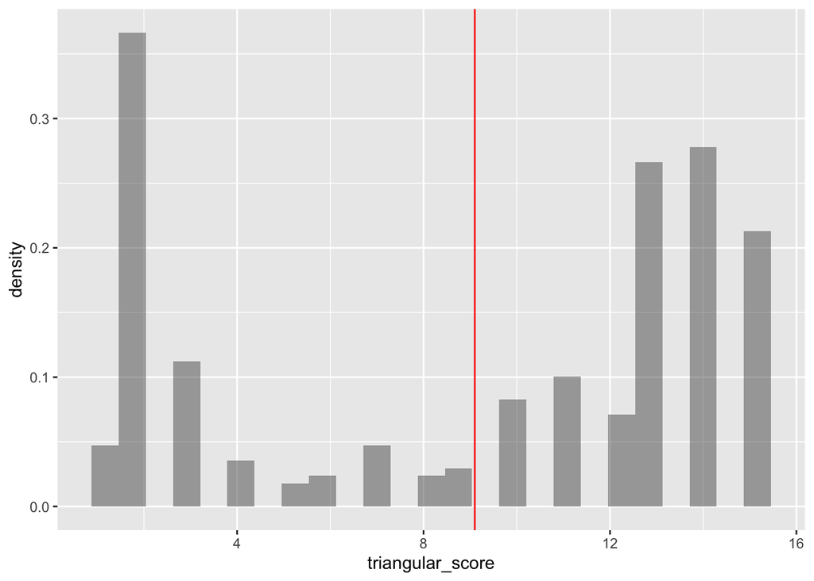

```r
#VISUALIZE distribution of response accuracy
gf_dhistogram(~triangular_score, data = df_subjects) %>%
  gf_vline(xintercept = score.stats$mean, color = "red")
```

Accuracy scores (n = 290) range from 1 to 15 with a mean score of (M = 9.1, SD = 5.22).

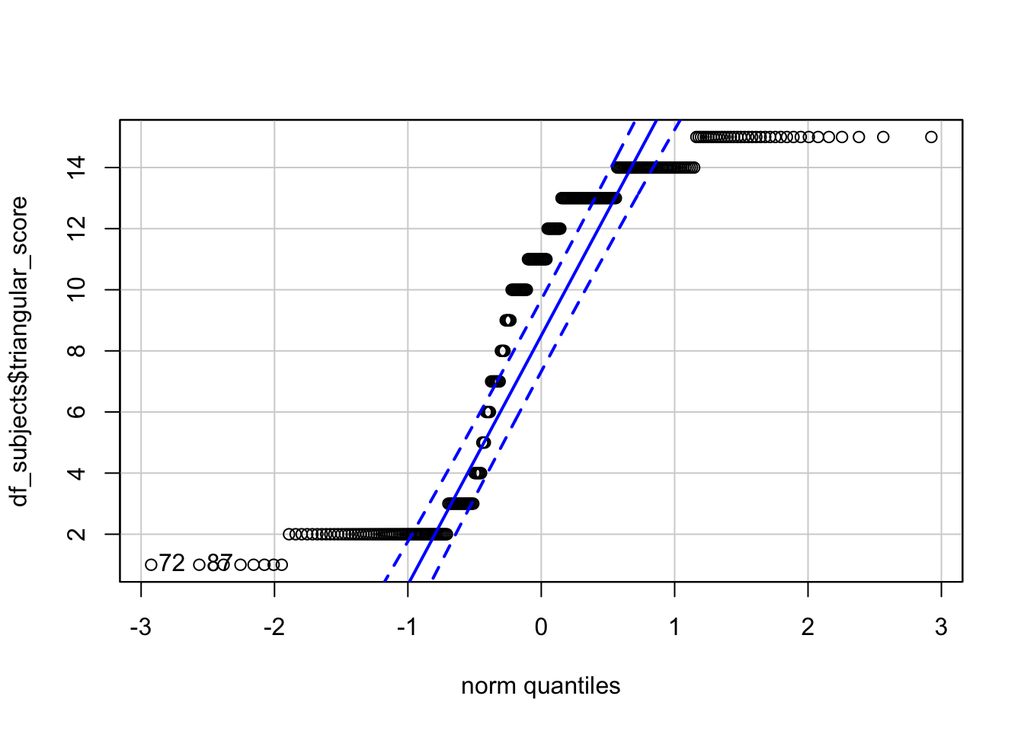

```
## [1] 72 87
```

```r
qqPlot(df_subjects$triangular_score)
```

## Response Latency

### TODO: Investigate response times

TODO: Investigate super high and super low response times..

```r
#DESCRIBE distribution of triangular-correct scores
time.stats <- favstats(df_subjects$tri_min)
time.stats
```

```
##       min       Q1   median       Q3      max     mean       sd   n missing
##  3.037067 6.269783 7.843792 9.655642 19.98955 8.242883 2.654231 290       0
```

```r
stat.desc(df_subjects$tri_min)
```

```
##      nbr.val     nbr.null       nbr.na          min          max        range
##  290.0000000    0.0000000    0.0000000    3.0370667   19.9895500   16.9524833
##          sum       median         mean      SE.mean CI.mean.0.95          var
## 2390.4361833    7.8437917    8.2428834    0.1558618    0.3067682    7.0449397
##      std.dev     coef.var
##    2.6542305    0.3220027
```

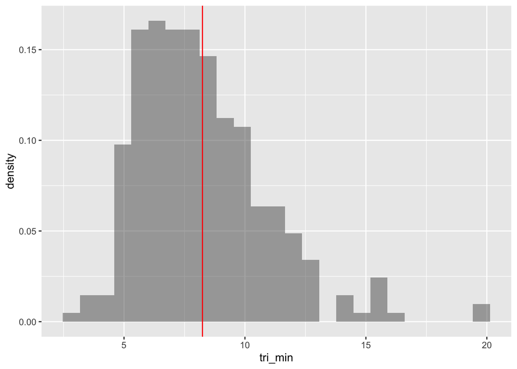

```r
#VISUALIZE distribution of response accuracy
gf_dhistogram(~tri_min, data = df_subjects) %>%
  gf_vline(xintercept = time.stats$mean, color = "red")
```

```r
shapiro.test(df_subjects$tri_min)
```

```
##
##  Shapiro-Wilk normality test
##
## data:  df_subjects$tri_min
## W = 0.93395, p-value = 4.502e-10
```

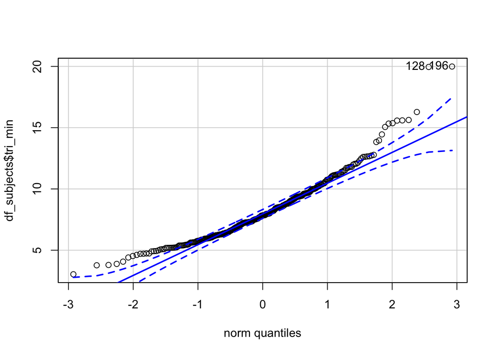

```
## [1] 196 128
```

```r
qqPlot(df_subjects$tri_min)
```

# HYPOTHESIS TESTING

## Response Accuracy by Condition

The experimental hypothesis (H1) is that explicit and implicit scaffolding will combine to improve performance, but implicit performance will have a greater impact on accuracy. The null hypothesis (H0) is that there will be no difference in performance between conditions.

### [EXPLORE]

```r
#DESCRIBE scores by condition
score.cond.stats <- favstats(triangular_score ~ condition, data = df_subjects)
score.cond.stats
```

```
##   condition min Q1 median    Q3 max      mean       sd  n missing
## 1       111   1  2    2.0  3.75  15  4.500000 4.643875 62       0
## 2       121   1  2    6.5 12.00  15  7.078125 4.828174 64       0
## 3       211   1  5   11.0 13.00  15  9.422222 4.726564 45       0
## 4       221   2 10   13.0 14.00  15 11.633333 3.633971 30       0
## 5       311   1 12   14.0 14.00  15 12.389831 3.459205 59       0
## 6       321   9 13   14.0 15.00  15 13.433333 1.501340 30       0
```

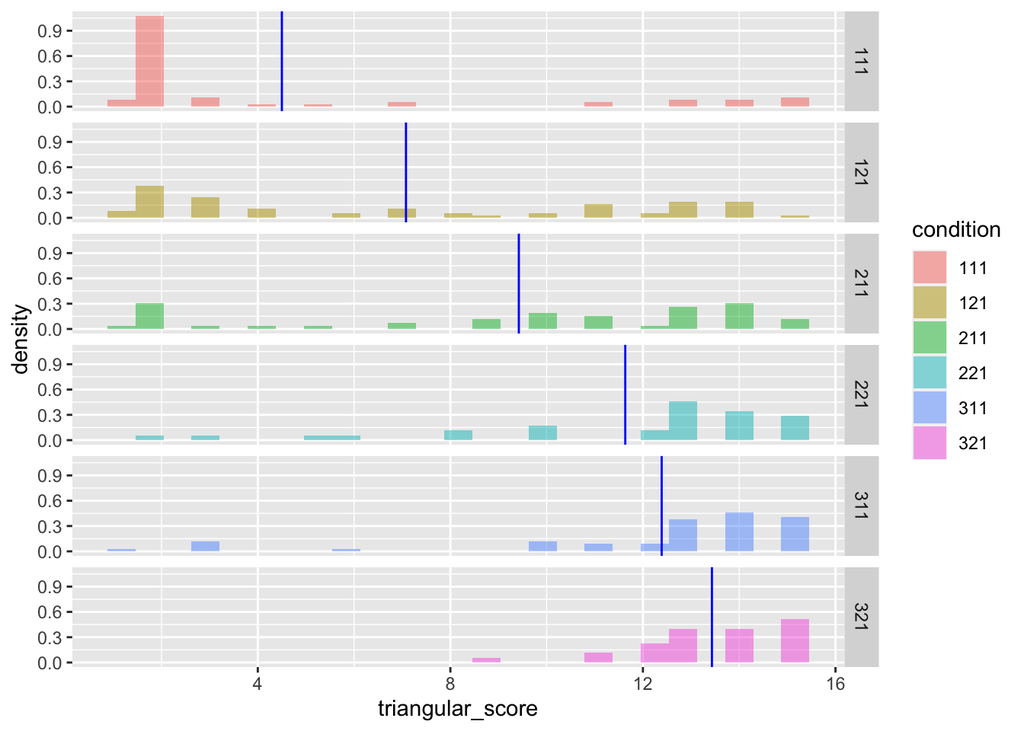

```r
#VISUALIZE scores by condition
gf_dhistogram( ~triangular_score, fill= ~condition, data = df_subjects) %>%
  gf_facet_grid(condition~.) %>%
  gf_vline(xintercept = ~mean, data = score.cond.stats, color = "blue")
```

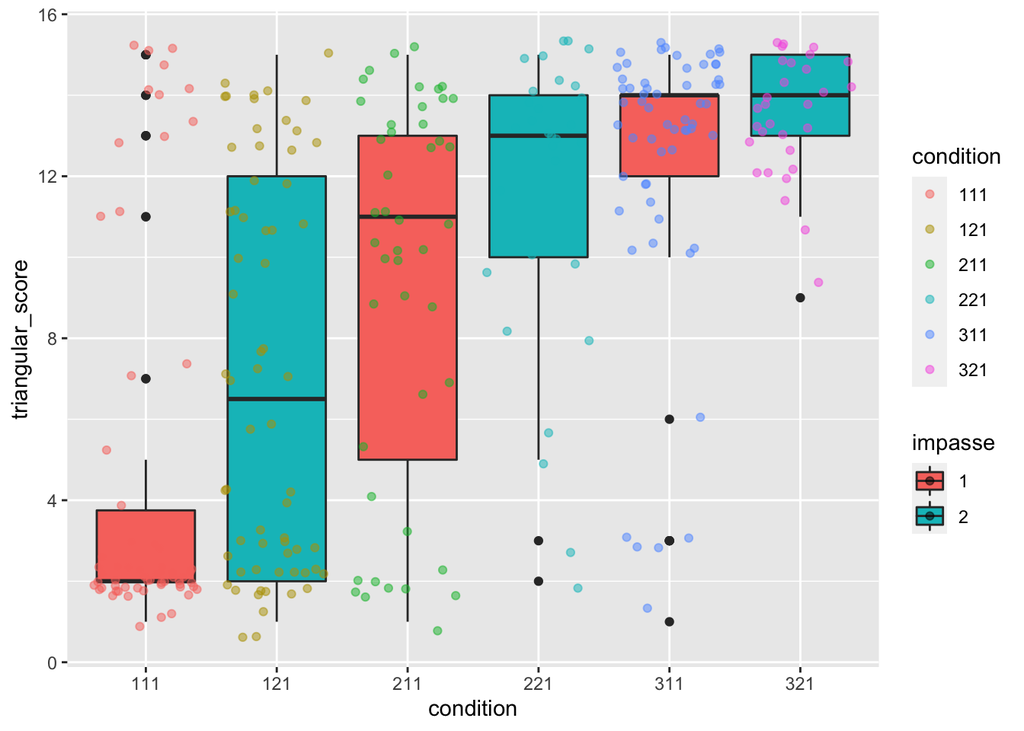

```r
#VISUALIZE scores by condition
gf_boxplot(triangular_score ~ condition, fill= ~impasse, data=df_subjects) %>%
  gf_jitter(color=~condition, alpha=0.5)
```

Accuracy scores (n = 290) range from 1 to 15 with a mean score of (M = 9.1, SD = 5.22). On average, participants in the impasse group had higher scores (M = 7.08 SD = 4.83) than those in #the non-impasse control group (M = 4.5, SD = 4.64)**

### [MODEL]

```r
#MODEL triangular score by condition with a linear model
m1 = lm(triangular_score ~ impasse*explicit, data = df_subjects)
m1
```

```
##
## Call:
## lm(formula = triangular_score ~ impasse * explicit, data = df_subjects)
##
## Coefficients:
##        (Intercept)            impasse2           explicit2           explicit3
##              4.500               2.578               4.922               7.890
## impasse2:explicit2  impasse2:explicit3
##             -0.367              -1.535
```

```r
# partition variance with anova
anova(m1)
```

```
## Analysis of Variance Table
##
## Response: triangular_score
##                   Df Sum Sq Mean Sq F value  Pr(>F)
## impasse            1   82.7   82.67  4.7820 0.02957 *
## explicit           2 2860.6 1430.29 82.7390 < 2e-16 ***
## impasse:explicit   2   29.4   14.70  0.8502 0.42842
## Residuals        284 4909.5   17.29
## ---
## Signif. codes:  0 '***' 0.001 '**' 0.01 '*' 0.05 '.' 0.1 ' ' 1
```

```r
# supernova(m1) #runs but doesn't knit?

#calculate effect size
eta_squared(m1, partial = FALSE)
```

```
## Parameter        |     Eta2 |       90% CI
## ------------------------------------------
## impasse          |     0.01 | [0.00, 0.04]
## explicit         |     0.36 | [0.29, 0.43]
## impasse:explicit | 3.73e-03 | [0.00, 0.02]
```

```r
score_summary <- df_subjects %>% group_by(condition) %>% summarise(mean = mean(triangular_score), se = sd(triangular_score)/sqrt(nrow(df_subjects)))
score_summary$impasse <- c('none','impasse','none','impasse','none','impasse')
score_summary$explicit <- c('none','none','static','static','interactive','interactive')
score_summary$impasse <- factor(score_summary$impasse, levels = c("none", "impasse"))
score_summary$explicit <- factor(score_summary$explicit, levels = c("none", "static", "interactive"))
score_summary
```

```
## # A tibble: 6 x 5
##   condition  mean     se impasse explicit
##   <fct>     <dbl>  <dbl> <fct>   <fct>
## 1 111        4.5  0.273  none    none
## 2 121        7.08 0.284  impasse none
## 3 211        9.42 0.278  none    static
## 4 221       11.6  0.213  impasse static
## 5 311       12.4  0.203  none    interactive
## 6 321       13.4  0.0882 impasse interactive
```

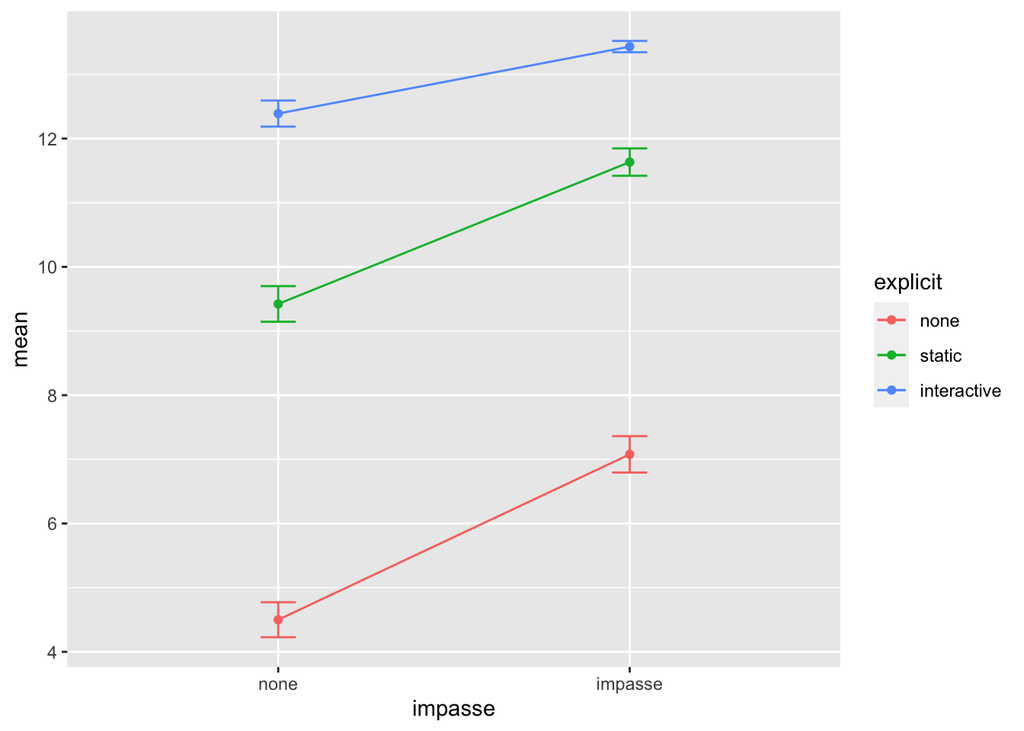

```r
ggplot(data = score_summary) +
  aes(x = impasse, color = explicit, group = explicit, y = mean) +
  stat_summary(fun.y = mean, geom = "point") +
  stat_summary(fun.y = mean, geom = "line") +
  geom_errorbar(aes(ymin=mean+se, ymax=mean-se), width=.1)
```

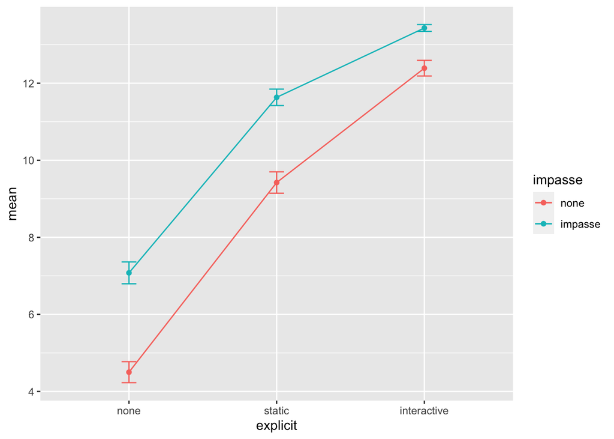

```r
ggplot(data = score_summary) +
  aes(x = explicit, color = impasse, group = impasse, y = mean) +
  stat_summary(fun.y = mean, geom = "point") +
  stat_summary(fun.y = mean, geom = "line") +
  geom_errorbar(aes(ymin=mean+se, ymax=mean-se), width=.1)
```

# POST-HOC EXPLORATION

## 1. Response Accuracy

## 1.1 Learning VS Testing

In SGC3B, participants are provided with 15 questions. For the first 5 questions, they experience a ‘scaffolded’ version the stimuli (control condition = 111, impasse scaffold = 121).

What if we **only** consider the final 10 test items? Assume students have 5 questions worth of scaffolding to figure out the graph for themselves, and we only assess accuracy for the final ten items? Is our experimental hypothesis supported?

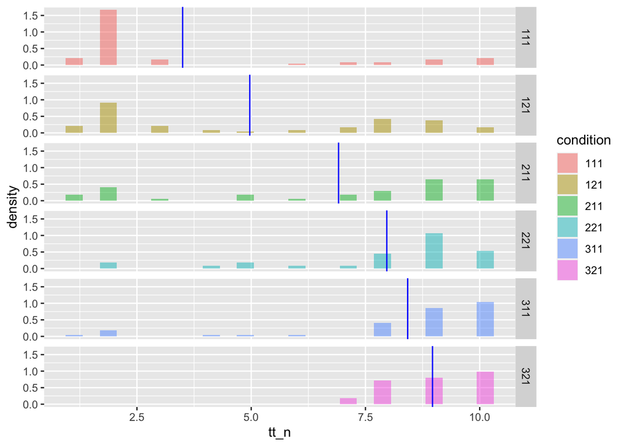

```r
#DESCRIBE scores by condition
test.stats <- favstats(tt_n ~ condition, data = df_subjects)

#VISUALIZE scores by condition
gf_dhistogram( ~tt_n, fill= ~condition, data = df_subjects) %>%
  gf_facet_grid(condition~.) %>%
  gf_vline(xintercept = ~mean, data = test.stats, color = "blue")
```

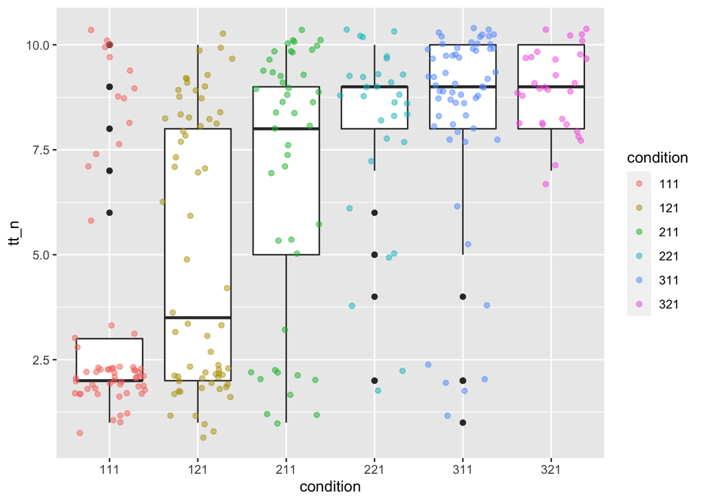

```r
#VISUALIZE scores by condition
gf_boxplot(tt_n ~ condition, data=df_subjects) %>%
  gf_jitter(color=~condition, alpha=0.5)
```

```r
mTest = lm(tt_n ~ impasse*explicit, data = df_subjects)
summary(mTest)
```

```
##
## Call:
## lm(formula = tt_n ~ impasse * explicit, data = df_subjects)
##
## Residuals:
##     Min      1Q  Median      3Q     Max
## -7.4237 -1.5000  0.0333  1.5763  6.5000
##
## Coefficients:
##                    Estimate Std. Error t value Pr(>|t|)
## (Intercept)          3.5000     0.3479  10.060  < 2e-16 ***
## impasse2             1.4688     0.4882   3.009  0.00286 **
## explicit2            3.4111     0.5365   6.358 8.12e-10 ***
## explicit3            4.9237     0.4982   9.882  < 2e-16 ***
## impasse2:explicit2  -0.4132     0.8095  -0.510  0.61014
## impasse2:explicit3  -0.9258     0.7847  -1.180  0.23903
## ---
## Signif. codes:  0 '***' 0.001 '**' 0.01 '*' 0.05 '.' 0.1 ' ' 1
##
## Residual standard error: 2.74 on 284 degrees of freedom
## Multiple R-squared:  0.3558, Adjusted R-squared:  0.3444
## F-statistic: 31.37 on 5 and 284 DF,  p-value: < 2.2e-16
```

```r
anova(mTest)
```

```
## Analysis of Variance Table
##
## Response: tt_n
##                   Df  Sum Sq Mean Sq F value Pr(>F)
## impasse            1   16.81   16.81  2.2393 0.1357
## explicit           2 1149.80  574.90 76.6020 <2e-16 ***
## impasse:explicit   2   10.49    5.24  0.6987 0.4981
## Residuals        284 2131.42    7.51
## ---
## Signif. codes:  0 '***' 0.001 '**' 0.01 '*' 0.05 '.' 0.1 ' ' 1
```

```r
# supernova(mTest)
```

## 2. Response Latency

### 2.1 Response Latency vs. Accuracy

Are response time (on the triangular blocks (test and learn)) and response accuracy correlated?

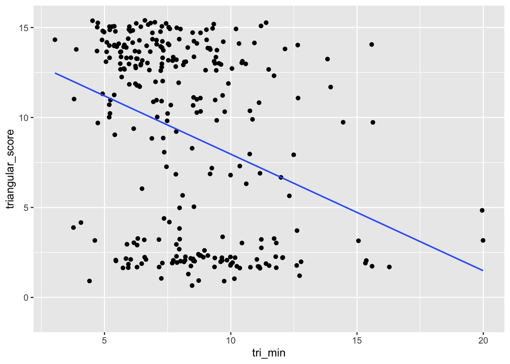

```r
#VISUALIZE relationship between response time and accuracy
gf_jitter(triangular_score ~ tri_min, data = df_subjects) %>%
  gf_lm()
```

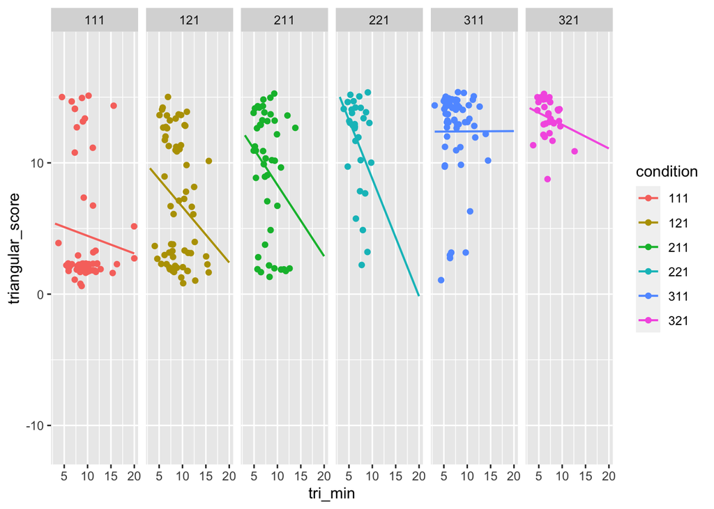

```r
#VISUALIZE relationship between response time and accuracy by condition
gf_jitter(triangular_score ~ tri_min, color = ~condition, data = df_subjects) %>%
  gf_facet_grid(~condition) %>%
  gf_lm()
```

From visual inspection, it does not *appear* that score and time and strongly correlated.

```r
#simple linear model predicting triangular score from triangular time
m1 = lm(triangular_score ~ tri_min, data = df_subjects)

summary(m1, correlation=TRUE)
```

```
##
## Call:
## lm(formula = triangular_score ~ tri_min, data = df_subjects)
##
## Residuals:
##     Min      1Q  Median      3Q     Max
## -10.586  -5.208   1.906   3.976   9.653
##
## Coefficients:
##             Estimate Std. Error t value Pr(>|t|)
## (Intercept)  14.4408     0.9479  15.235  < 2e-16 ***
## tri_min      -0.6479     0.1095  -5.919 9.21e-09 ***
## ---
## Signif. codes:  0 '***' 0.001 '**' 0.01 '*' 0.05 '.' 0.1 ' ' 1
##
## Residual standard error: 4.94 on 288 degrees of freedom
## Multiple R-squared:  0.1084, Adjusted R-squared:  0.1053
## F-statistic: 35.03 on 1 and 288 DF,  p-value: 9.211e-09
##
## Correlation of Coefficients:
##         (Intercept)
## tri_min -0.95
```

```r
cor.test(df_subjects$triangular_score, df_subjects$tri_min)
```

```
##
##  Pearson's product-moment correlation
##
## data:  x and y
## t = -5.9186, df = 288, p-value = 9.211e-09
## alternative hypothesis: true correlation is not equal to 0
## 95 percent confidence interval:
##  -0.4282413 -0.2225668
## sample estimates:
##        cor
## -0.3293046
```

A linear regression indicates a significant (though small) negative correlation between score accuracy and response time r = -0.33, t(288) = -5.92, p < 0.001.

### 2.2 Response Latency by Condition

Do response times differ by condition?

```r
time.stats <- favstats(tri_min ~ condition, data = df_subjects)
time.stats
```

```
##   condition      min       Q1   median        Q3       max     mean       sd  n
## 1       111 3.770800 7.734442 9.137217 10.898175 19.989550 9.549685 3.094600 62
## 2       121 4.067033 7.018921 8.525967 10.632429 15.627183 8.965625 2.696314 64
## 3       211 4.901833 6.302750 7.480533  9.356467 13.830783 7.969075 2.225351 45
## 4       221 3.882283 5.685875 6.439567  7.911067  9.759317 6.819759 1.526557 30
## 5       311 3.037067 5.667433 7.272083  8.849542 14.450267 7.594927 2.442965 59
## 6       321 3.796267 6.062646 6.967167  7.834079 12.664017 7.108463 1.813312 30
##   missing
## 1       0
## 2       0
## 3       0
## 4       0
## 5       0
## 6       0
```

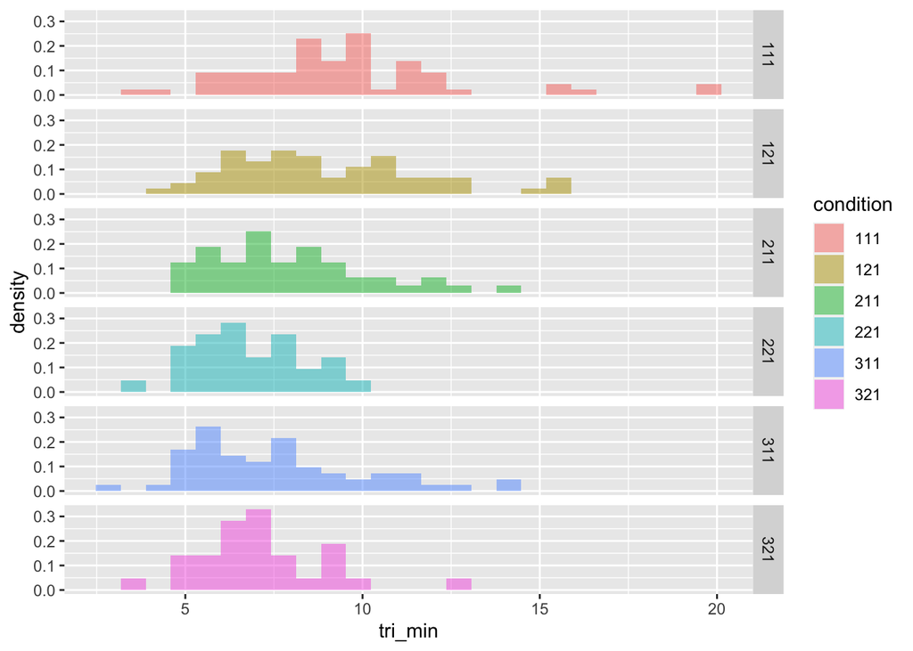

```r
gf_dhistogram(~tri_min, fill = ~condition, data = df_subjects) %>%
  gf_facet_grid(condition~.)
```

```r
m1 <- lm(tri_min ~ condition, data = df_subjects)
summary(m1)
```

```
##
## Call:
## lm(formula = tri_min ~ condition, data = df_subjects)
##
## Residuals:
##     Min      1Q  Median      3Q     Max
## -5.7789 -1.6938 -0.3511  1.4295 10.4399
##
## Coefficients:
##              Estimate Std. Error t value Pr(>|t|)
## (Intercept)    9.5497     0.3170  30.127  < 2e-16 ***
## condition121  -0.5841     0.4448  -1.313  0.19017
## condition211  -1.5806     0.4888  -3.234  0.00137 **
## condition221  -2.7299     0.5551  -4.918 1.48e-06 ***
## condition311  -1.9548     0.4539  -4.306 2.29e-05 ***
## condition321  -2.4412     0.5551  -4.398 1.55e-05 ***
## ---
## Signif. codes:  0 '***' 0.001 '**' 0.01 '*' 0.05 '.' 0.1 ' ' 1
##
## Residual standard error: 2.496 on 284 degrees of freedom
## Multiple R-squared:  0.1311, Adjusted R-squared:  0.1158
## F-statistic: 8.566 on 5 and 284 DF,  p-value: 1.424e-07
```

```r
# supernova(m1)
```

The difference in average response time IS statistically significant F(5,284) = 8.57 , p < 0.01, with a linear model predicting response time from condition explaining only 13% of variance in response time.

### 2.2 Is Response Latency predictive?

Does adding response time to the model help predict score accuracy?

```r
#simple  model predicting triangular score from triangular time
m1 = lm(triangular_score ~ impasse*explicit, data = df_subjects)
m2 = lm(triangular_score ~ impasse*explicit+ tri_min, data = df_subjects)
summary(m1)
```

```
##
## Call:
## lm(formula = triangular_score ~ impasse * explicit, data = df_subjects)
##
## Residuals:
##      Min       1Q   Median       3Q      Max
## -11.3898  -2.5000   0.5667   2.6102  10.5000
##
## Coefficients:
##                    Estimate Std. Error t value Pr(>|t|)
## (Intercept)          4.5000     0.5280   8.522 9.36e-16 ***
## impasse2             2.5781     0.7409   3.480 0.000581 ***
## explicit2            4.9222     0.8142   6.045 4.68e-09 ***
## explicit3            7.8898     0.7562  10.434  < 2e-16 ***
## impasse2:explicit2  -0.3670     1.2285  -0.299 0.765357
## impasse2:explicit3  -1.5346     1.1909  -1.289 0.198563
## ---
## Signif. codes:  0 '***' 0.001 '**' 0.01 '*' 0.05 '.' 0.1 ' ' 1
##
## Residual standard error: 4.158 on 284 degrees of freedom
## Multiple R-squared:  0.3771, Adjusted R-squared:  0.3662
## F-statistic: 34.39 on 5 and 284 DF,  p-value: < 2.2e-16
```

```r
summary(m2)
```

```
##
## Call:
## lm(formula = triangular_score ~ impasse * explicit + tri_min,
##     data = df_subjects)
##
## Residuals:
##      Min       1Q   Median       3Q      Max
## -12.2327  -2.7492   0.4342   2.5143  11.0935
##
## Coefficients:
##                    Estimate Std. Error t value Pr(>|t|)
## (Intercept)         7.02400    1.06981   6.566 2.47e-10 ***
## impasse2            2.42376    0.73502   3.298  0.00110 **
## explicit2           4.50446    0.82003   5.493 8.80e-08 ***
## explicit3           7.37318    0.77196   9.551  < 2e-16 ***
## tri_min            -0.26430    0.09777  -2.703  0.00728 **
## impasse2:explicit2 -0.51641    1.21637  -0.425  0.67149
## impasse2:explicit3 -1.50883    1.17789  -1.281  0.20126
## ---
## Signif. codes:  0 '***' 0.001 '**' 0.01 '*' 0.05 '.' 0.1 ' ' 1
##
## Residual standard error: 4.112 on 283 degrees of freedom
## Multiple R-squared:  0.3928, Adjusted R-squared:  0.3799
## F-statistic: 30.51 on 6 and 283 DF,  p-value: < 2.2e-16
```

```r
anova(m1) # supernova(m1)
```

```
## Analysis of Variance Table
##
## Response: triangular_score
##                   Df Sum Sq Mean Sq F value  Pr(>F)
## impasse            1   82.7   82.67  4.7820 0.02957 *
## explicit           2 2860.6 1430.29 82.7390 < 2e-16 ***
## impasse:explicit   2   29.4   14.70  0.8502 0.42842
## Residuals        284 4909.5   17.29
## ---
## Signif. codes:  0 '***' 0.001 '**' 0.01 '*' 0.05 '.' 0.1 ' ' 1
```

```r
anova(m2) # supernova(m2)
```

```
## Analysis of Variance Table
##
## Response: triangular_score
##                   Df Sum Sq Mean Sq F value  Pr(>F)
## impasse            1   82.7   82.67  4.8882 0.02784 *
## explicit           2 2860.6 1430.29 84.5767 < 2e-16 ***
## tri_min            1  125.2  125.17  7.4017 0.00692 **
## impasse:explicit   2   27.8   13.90  0.8222 0.44052
## Residuals        283 4785.9   16.91
## ---
## Signif. codes:  0 '***' 0.001 '**' 0.01 '*' 0.05 '.' 0.1 ' ' 1
```

TODO: What is the appropriate inference to draw from this model comparison?.

### 2.3. Response Latency on Learn (v) Test

```r
#DESCRIBE distribution of learning block times scores
learn.time.stats <- favstats(df_subjects$learn_min)
learn.time.stats
```

```
##        min       Q1   median       Q3      max     mean       sd   n missing
##  0.5265667 2.221904 3.051617 4.254275 11.10467 3.377125 1.599774 290       0
```

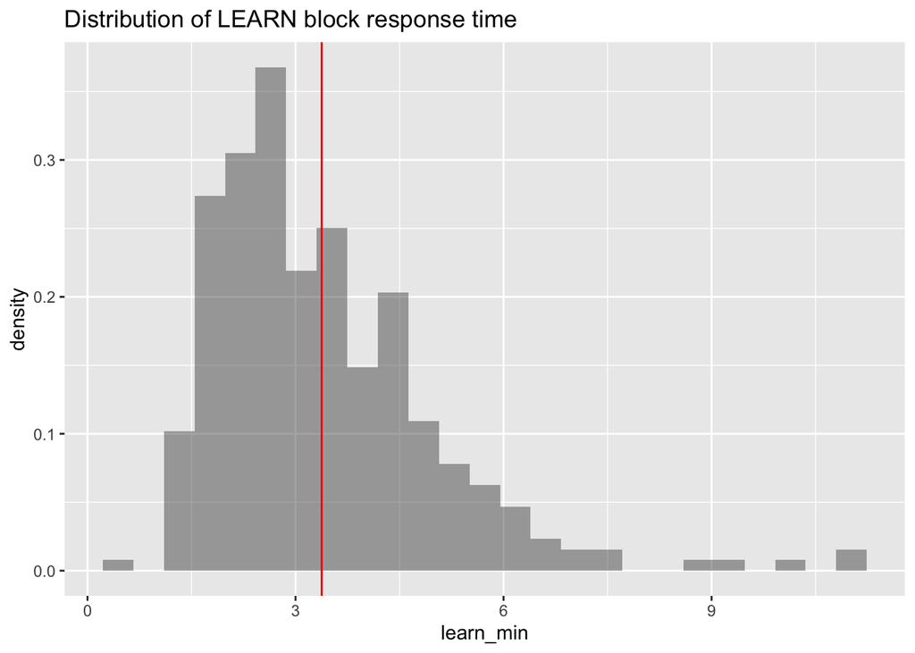

```r
#VISUALIZE distribution of learning block time
gf_dhistogram(~learn_min, data = df_subjects) %>%
  gf_vline(xintercept = mean(df_subjects$learn_min), color = "red") %>%
  gf_labs(title = "Distribution of LEARN block response time ")
```

Total learning block times ranged from 0.53 min to 11.1, with M = 3.38, SD = 1.6.

```r
#DESCRIBE distribution of learning block times scores
test.time.stats <- favstats(df_subjects$test_min)
test.time.stats
```

```
##      min       Q1   median       Q3      max     mean       sd   n missing
##  2.07735 3.774096 4.727458 5.630387 14.53573 4.865759 1.587424 290       0
```

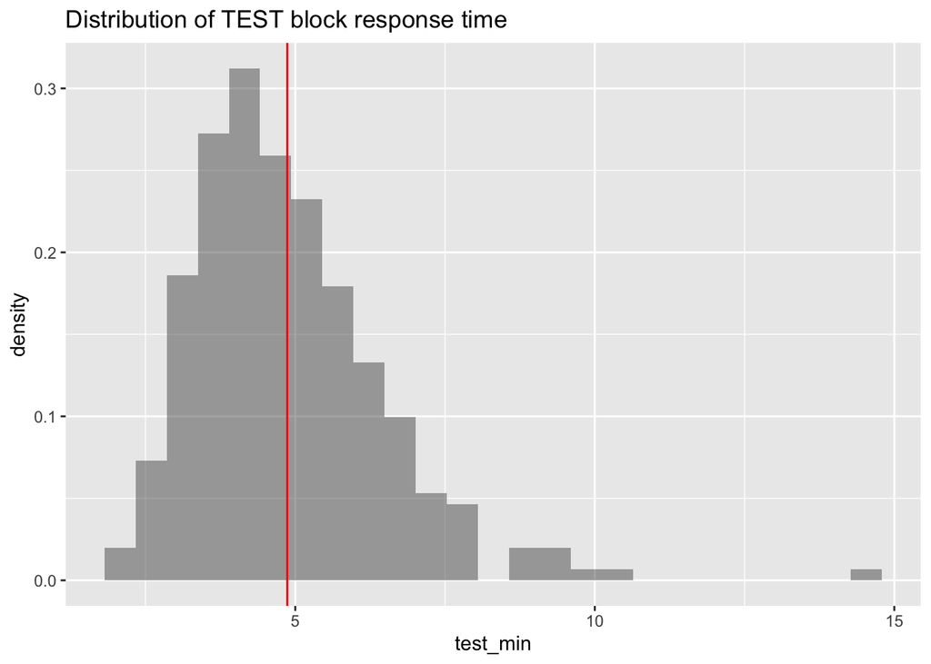

```r
#VISUALIZE distribution of learning block time
gf_dhistogram(~test_min, data = df_subjects) %>%
  gf_vline(xintercept = mean(df_subjects$test_min), color = "red") %>%
  gf_labs(title = "Distribution of TEST block response time ")
```

Total testing block times ranged from 2.08 min to 14.54, with M = 4.87, SD = 1.59.

Is time spent on learning (v) testing blocks correlated?

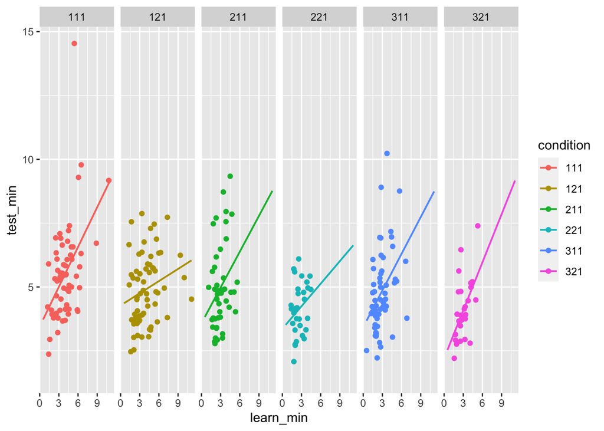

```r
#VISUALIZE test v learning block time
gf_point(test_min ~ learn_min, color = ~condition, data = df_subjects) %>%
  gf_facet_grid(~condition) %>%
  gf_lm()
```

```r
m1 <- lm( test_min ~ learn_min , data = df_subjects)
summary(m1)
```

```
##
## Call:
## lm(formula = test_min ~ learn_min, data = df_subjects)
##
## Residuals:
##     Min      1Q  Median      3Q     Max
## -3.3110 -0.9780 -0.2142  0.7398  8.8861
##
## Coefficients:
##             Estimate Std. Error t value Pr(>|t|)
## (Intercept)  3.56880    0.20141  17.719  < 2e-16 ***
## learn_min    0.38404    0.05391   7.123 8.46e-12 ***
## ---
## Signif. codes:  0 '***' 0.001 '**' 0.01 '*' 0.05 '.' 0.1 ' ' 1
##
## Residual standard error: 1.466 on 288 degrees of freedom
## Multiple R-squared:  0.1498, Adjusted R-squared:  0.1468
## F-statistic: 50.74 on 1 and 288 DF,  p-value: 8.463e-12
```

```r
anova(m1) #supernova(m1)
```

```
## Analysis of Variance Table
##
## Response: test_min
##            Df Sum Sq Mean Sq F value    Pr(>F)
## learn_min   1 109.09  109.09  50.741 8.463e-12 ***
## Residuals 288 619.17    2.15
## ---
## Signif. codes:  0 '***' 0.001 '**' 0.01 '*' 0.05 '.' 0.1 ' ' 1
```

```r
cor.test(df_subjects$test_min, df_subjects$learn_min)
```

```
##
##  Pearson's product-moment correlation
##
## data:  x and y
## t = 7.1233, df = 288, p-value = 8.463e-12
## alternative hypothesis: true correlation is not equal to 0
## 95 percent confidence interval:
##  0.2845356 0.4807785
## sample estimates:
##       cor
## 0.3870311
```

A linear model predicting test block time from learning block time reveals that learning block time explains 15% variance in testing block time (F(1,288) = 50.7, p < 0.001), with an 23s increase in testing time for every 1 minute increase in learning time. The two variables have a small, significant correlation r = 0.39, t(288) = 7.12, p < 0.001, 95% CI [0.28, 0.48].